# MP2

Jaan Selod and Tess Webb-Johnson

2024-02-08

# Introduction:

In this project, we explored the forearm as a third-order lever system, considering especially how skeletal structure, muscle length, and muscle mass affect force output and maximum load a system can support. The forearm is a classic example of a biological third-order lever system, as the “effort” (the biceps) is positioned between the fulcrum (the elbow, assumed to function as a hinge joint) and the load (held in the palm) (Davis (n.d.)). The specific goals were to predict the force and torque produced by the biceps system at the outlever position over a range of angles and test those predictions. We answered by constructing a computational model and assessing our predictions at the gym.

# Methods:

To construct a dynamic-equilibrium-based computational model, we obtained biometric data pertaining to the biceps brachii system of the arm. Muscle mass was estimated by manipulating clay into the size and shape of the biceps and measuring this mass. Arm length was measured as the distance between the origin of the muscle at the scapular coracoid process and the inserting tendon on the proximal forearm. Inlever length was measured as the length between elbow joint and insertion point, and outlever length as the distance between elbow joint and middle of the palm. Muscle length as a function of flexion angle was calculated using the cosine law and included the measured data of arm length and inlever length. These muscle length ranges were then used in another cosine calculation to determine insertion angle ranges for flexion angles. The torque model was designed such that muscle torque depended on muscle force, insertion angle, and inlever length:
$$\tau_{muscle} = F_{muscle}\cdot\sin(\theta)\cdot L_i$$

# Results:

Table 1: Predicted Muscle Torque and Maximum Load

| Subject | flexion | Lmuscle | theta | muscle_torque | max_mass |
| --- | --- | --- | --- | --- | --- |
| Jaan | 0.8726646 | 0.2298089 | 1.439305 | 28.838804 | 10.499055 |
| Jaan | 1.3089969 | 0.2588684 | 1.441979 | 32.094887 | 11.684465 |
| Jaan | 1.7453293 | 0.2881097 | 1.439490 | 30.421633 | 11.075300 |
| Jaan | 2.1816616 | 0.3127270 | 1.434077 | 25.170761 | 9.163667 |
| Jaan | 2.6179939 | 0.3295665 | 1.428847 | 19.563138 | 7.122156 |
| Tess | 0.8726646 | 0.2900970 | 1.488759 | 15.092149 | 5.494448 |
| Tess | 1.3089969 | 0.3148508 | 1.481890 | 15.085782 | 5.492130 |
| Tess | 1.7453293 | 0.3405837 | 1.472180 | 13.723387 | 4.996136 |
| Tess | 2.1816616 | 0.3627595 | 1.461912 | 11.443945 | 4.166283 |
| Tess | 2.6179939 | 0.3781534 | 1.453822 | 9.262415 | 3.372075 |

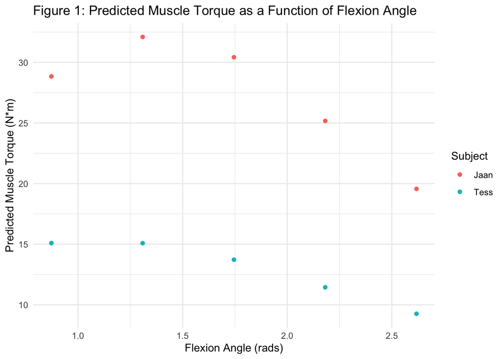

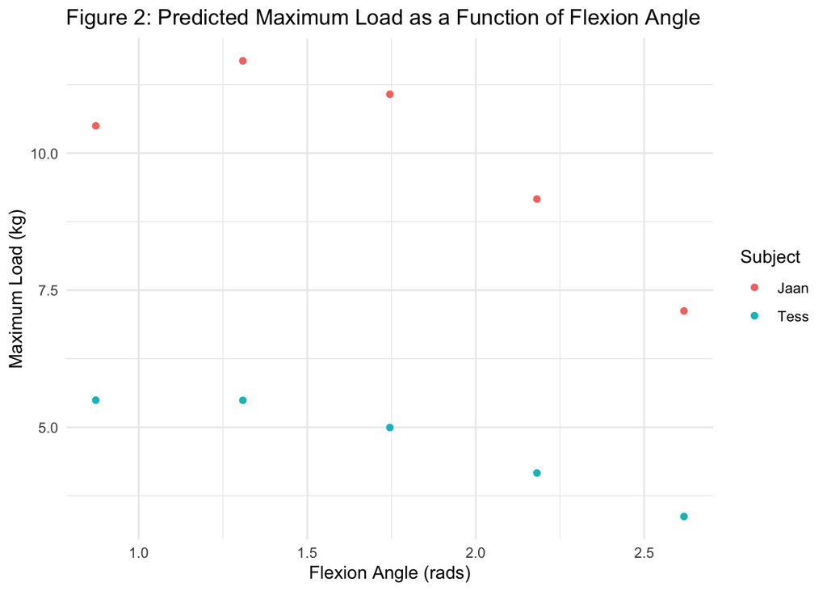